# Data Train | OT-SC-WS-04: Evaluating machine learning and artificial intelligence algorithms

Max Westphal (max.westphal@mevis.fraunhofer.de)

Pascal Rink (p.rink@uni-bremen.de)

# R session 1: ML performance evaluation basics

```r
## clear enviroment:
rm(list = ls())

## calc_costly determines if computationally expensive steps should be run during notebook rendering:
calc_costly <- FALSE

## calc_costly determines if certain intermediate variables should be saved during notebook rendering:
save_vars <- FALSE
```

```r
library(dplyr)
library(mlr3verse)
```

## Exercise 1: mlr3 basics (30 minutes)

Throughout the entire course, we will make heavy use of the r package **mlr3**. We will spend some time in the beginning to get familiar with the (somewhat special) R6 syntax employed by mlr3.

For this matter, please go through the excellent **mlr3 book** at https://mlr3book.mlr-org.com/index.html, in particular the first two sections “Introduction and Overview” and “Basics”. You can open a separate R script (ctrl-shift-n) and experiment with the code from the book yourself.

We encourage you to revisit the mlr3 book whenever you need help during the course. In addition, a wide variety of code examples is provided in the **mlr3 gallery** at https://mlr3gallery.mlr-org.com/.

Finally, we provide you with some basic knowledge for the ML algorithms employed in this course:

- logistic regression (lr): https://en.wikipedia.org/wiki/Logistic_regression
- support vector machine (svm): https://en.wikipedia.org/wiki/Support-vector_machine
- random forest (rf): https://en.wikipedia.org/wiki/Support-vector_machine
- extreme gradient boosting (xgb): https://en.wikipedia.org/wiki/XGBoost

Let’s have a look at the corresponding **learner** representations in mlr3, which show some fundamental properties.

```r
mlr_learners$get("classif.log_reg")
```

```
## <LearnerClassifLogReg:classif.log_reg>
## * Model: -
## * Parameters: list()
## * Packages: stats
## * Predict Type: response
## * Feature types: logical, integer, numeric, character, factor, ordered
## * Properties: loglik, twoclass, weights
```

```r
mlr_learners$get("classif.svm")
```

```
## <LearnerClassifSVM:classif.svm>
## * Model: -
## * Parameters: list()
## * Packages: e1071
## * Predict Type: response
## * Feature types: logical, integer, numeric
## * Properties: multiclass, twoclass
```

```r
mlr_learners$get("classif.ranger")
```

```
## <LearnerClassifRanger:classif.ranger>
## * Model: -
## * Parameters: num.threads=1
## * Packages: ranger
## * Predict Type: response
## * Feature types: logical, integer, numeric, character, factor, ordered
## * Properties: importance, multiclass, oob_error, twoclass, weights
```

```r
mlr_learners$get("classif.xgboost")
```

```
## <LearnerClassifXgboost:classif.xgboost>
## * Model: -
## * Parameters: nrounds=1, nthread=1, verbose=0
## * Packages: xgboost
## * Predict Type: response
## * Feature types: logical, integer, numeric
## * Properties: importance, missings, multiclass, twoclass, weights
```

## Exercise 2: Preparation of breast cancer task and EDA (30 minutes)

Today, we will focus on the breast cancer task included in the mlr3 package. Our goal will be to predict the `class` variable, i.e. whether a certain tumor is malignant or benign. Let’s have a look at the data.

```r
bc_task <- tsk("breast_cancer")
bc_task$data()
```

| class | bare_nuclei | bl_cromatin | cell_shape | cell_size | cl_thickness | epith_c_size | marg_adhesion | mitoses | normal_nucleoli |
| --- | --- | --- | --- | --- | --- | --- | --- | --- | --- |
| benign | 1 | 3 | 1 | 1 | 5 | 2 | 1 | 1 | 1 |
| benign | 10 | 3 | 4 | 4 | 5 | 7 | 5 | 1 | 2 |
| benign | 2 | 3 | 1 | 1 | 3 | 2 | 1 | 1 | 1 |
| benign | 4 | 3 | 8 | 8 | 6 | 3 | 1 | 1 | 7 |
| benign | 1 | 3 | 1 | 1 | 4 | 2 | 3 | 1 | 1 |
| malignant | 10 | 9 | 10 | 10 | 8 | 7 | 8 | 1 | 7 |
| benign | 10 | 3 | 1 | 1 | 1 | 2 | 1 | 1 | 1 |
| benign | 1 | 3 | 2 | 1 | 2 | 2 | 1 | 1 | 1 |
| benign | 1 | 1 | 1 | 1 | 2 | 2 | 1 | 5 | 1 |
| benign | 1 | 2 | 1 | 2 | 4 | 2 | 1 | 1 | 1 |

[output cut: 673 more lines]

As we can see, the data set contains 683 observations of the target variable and nine features, which can be used for prediction. Please read the documentation below:

```r
bc_task$help()
```

Before we do anything, lets split our data. As the total number of samples seems sufficient, we adopt the default 3-way training-validation-test split to get started. While `mlr3` is great, it is limited with regards to performing statistical inference (confidence intervals, statistical testing) on the test data.

We will first split off a test data set and not look at it until the very end. We will use a random 25% of observations (rows) for testing:

```r
set.seed(122333)
obs_ids <- 1:bc_task$nrow
test_ids <- sample(obs_ids, round(0.25*length(obs_ids)))
length(test_ids)
```

```
## [1] 171
```

```r
if(save_vars){
  saveRDS(test_ids, "data/session1/bc_test_ids.rds")
}
test_ids <- readRDS("data/session1/bc_test_ids.rds")
```

**Task: Define the `learn_ids` (observations for training & validation) as the remaining rows.**

```r
learn_ids <- setdiff(obs_ids, test_ids)
```

```r
bc_data <- bc_task$data()
bc_data_learn <- bc_data[learn_ids, ]
bc_data_test <- bc_data[test_ids, ]

bc_task$filter(rows=learn_ids)
```

In the original `"breast_cancer"` task, the features are encoded as ordinal. Not all learning algorithms are able to cope with ordinal features though. For this reason, we derive an identical task where all features are converted to `numeric` variables.

```r
apply(bc_data_learn, 2, class)
```

```
##           class     bare_nuclei     bl_cromatin      cell_shape       cell_size
##     "character"     "character"     "character"     "character"     "character"
##    cl_thickness    epith_c_size   marg_adhesion         mitoses normal_nucleoli
##     "character"     "character"     "character"     "character"     "character"
```

```r
bc_data_num <- bc_data %>% mutate_at(2:10, as.numeric)
bc_data_learn_num <- bc_data_learn %>% mutate_at(2:10, as.numeric)
bc_data_test_num <- bc_data_test %>% mutate_at(2:10, as.numeric)

bc_task_num <- as_task_classif(bc_data_learn_num,
                               target="class",
                               id="bc_task_num")
```

Let’s have a look at the complete learning data (not the test data, which we have excluded from the task).

```r
summary(bc_data_learn)
```

```
##        class      bare_nuclei   bl_cromatin    cell_shape    cell_size
##  malignant:175   1      :309   2      :132   1      :260   1      :287
##  benign   :337   10     : 97   1      :116   2      : 45   10     : 50
##                  5      : 28   3      :114   10     : 44   3      : 38
##                  3      : 22   7      : 54   3      : 42   2      : 33
##                  2      : 19   4      : 27   4      : 34   4      : 27
##                  8      : 12   5      : 24   6      : 22   8      : 20
##                  (Other): 25   (Other): 45   (Other): 65   (Other): 57
##   cl_thickness  epith_c_size marg_adhesion    mitoses    normal_nucleoli
##  1      :98    2      :290   1      :304   1      :425   1      :328
##  5      :95    3      : 48   10     : 41   2      : 26   10     : 44
##  3      :83    4      : 37   3      : 40   3      : 24   3      : 32
##  4      :60    6      : 32   2      : 39   10     : 12   2      : 26
##  10     :52    1      : 31   4      : 23   4      :  8   8      : 16
##  2      :41    5      : 26   8      : 20   7      :  7   5      : 15
##  (Other):83    (Other): 48   (Other): 45   (Other): 10   (Other): 51
```

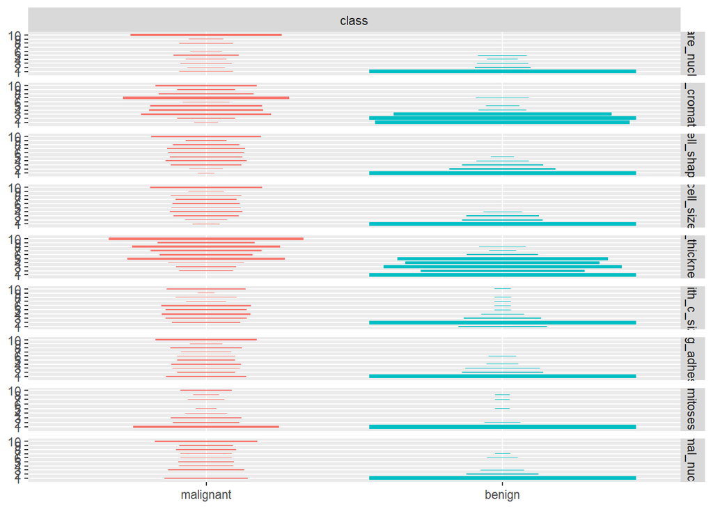

```r
autoplot(bc_task, type = "duo")
```

```r
summary(bc_data_learn_num)
```

```
##        class      bare_nuclei      bl_cromatin       cell_shape
##  malignant:175   Min.   : 1.000   Min.   : 1.000   Min.   : 1.000
##  benign   :337   1st Qu.: 1.000   1st Qu.: 2.000   1st Qu.: 1.000
##                  Median : 1.000   Median : 3.000   Median : 1.000
##                  Mean   : 3.451   Mean   : 3.359   Mean   : 3.174
##                  3rd Qu.: 5.000   3rd Qu.: 4.000   3rd Qu.: 5.000
##                  Max.   :10.000   Max.   :10.000   Max.   :10.000
##    cell_size       cl_thickness     epith_c_size    marg_adhesion
##  Min.   : 1.000   Min.   : 1.000   Min.   : 1.000   Min.   : 1.000
##  1st Qu.: 1.000   1st Qu.: 2.000   1st Qu.: 2.000   1st Qu.: 1.000
##  Median : 1.000   Median : 4.000   Median : 2.000   Median : 1.000
##  Mean   : 3.102   Mean   : 4.463   Mean   : 3.229   Mean   : 2.814
##  3rd Qu.: 4.000   3rd Qu.: 6.000   3rd Qu.: 4.000   3rd Qu.: 4.000
##  Max.   :10.000   Max.   :10.000   Max.   :10.000   Max.   :10.000
##     mitoses      normal_nucleoli
##  Min.   :1.000   Min.   : 1.00
##  1st Qu.:1.000   1st Qu.: 1.00
##  Median :1.000   Median : 1.00
##  Mean   :1.568   Mean   : 2.83
##  3rd Qu.:1.000   3rd Qu.: 3.00
##  Max.   :9.000   Max.   :10.00
```

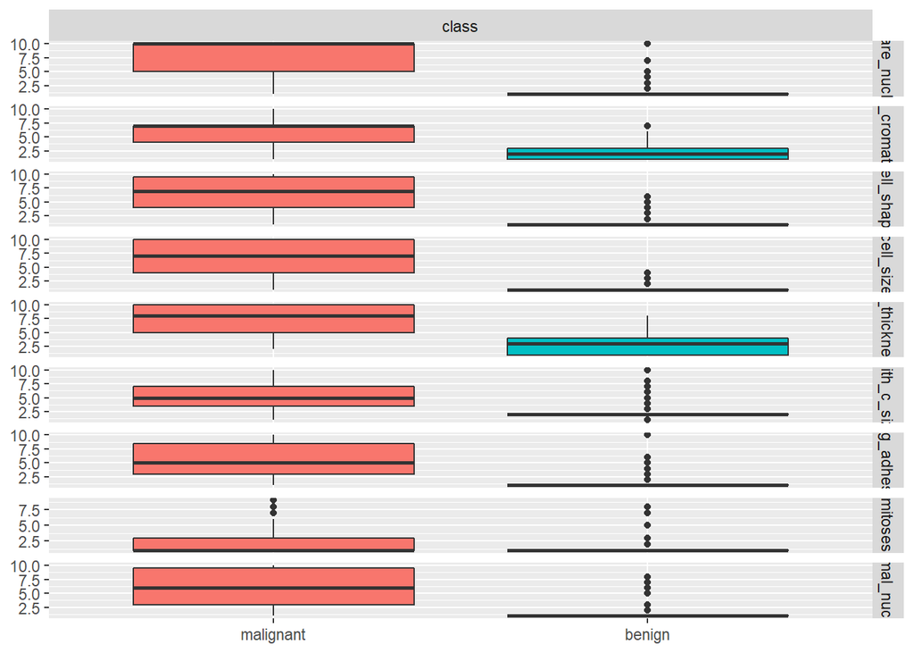

```r
autoplot(bc_task_num, type = "duo")
```

**Question: What features do you suspect to be predictive for the target variable**?

- In particular the first five features as they clearly show a different (empirical) distribution in the `malignant` and `benign` samples.

**Question: Why is it, strictly speaking, not valid to ask the same question when looking at the complete data set (including the test data)?**

- Because information from the test data might leak, i.e. influence our model development (and particular) selection process such that the final performance assessment on the test data will potentially be biased.

## Exercise 3: Training, prediction and inference with SVM (30 minutes)

Let’s start with logistic regression, an established statistical classification model. We will just use it as a baseline, i.e. try to beat it with other classification models.

```r
lr_learner <- lrn("classif.log_reg")
lr_learner$train(bc_task_num)
```

A great advantage of such a simple model is it’s interpretability.

```r
lr_learner$model %>% summary()
```

```
##
## Call:
## stats::glm(formula = task$formula(), family = "binomial", data = data,
##     model = FALSE)
##
## Deviance Residuals:
##     Min       1Q   Median       3Q      Max
## -3.2368  -0.0869  -0.0464   0.0074   2.6428
##
## Coefficients:
##                  Estimate Std. Error z value Pr(>|z|)
## (Intercept)     -10.30595    1.49657  -6.886 5.72e-12 ***
## bare_nuclei       0.51064    0.15476   3.300 0.000968 ***
## bl_cromatin       0.09359    0.22980   0.407 0.683821
## cell_shape        0.60851    0.35148   1.731 0.083405 .
## cell_size         0.47204    0.32638   1.446 0.148103
## cl_thickness      0.54862    0.19563   2.804 0.005042 **
## epith_c_size      0.02437    0.20290   0.120 0.904417
## marg_adhesion     0.09560    0.16596   0.576 0.564580
## mitoses           0.35362    0.39248   0.901 0.367603
## normal_nucleoli   0.16445    0.14468   1.137 0.255693
## ---
## Signif. codes:  0 '***' 0.001 '**' 0.01 '*' 0.05 '.' 0.1 ' ' 1
##
## (Dispersion parameter for binomial family taken to be 1)
##
##     Null deviance: 657.633  on 511  degrees of freedom
## Residual deviance:  59.812  on 502  degrees of freedom
## AIC: 79.812
##
## Number of Fisher Scoring iterations: 9
```

**Question: based on the above output - what can we learn regarding the importance of individual features?**

- The features `bare_nuclei` and `cl_thickness` are strong predictors as they show a significant association with the target variable (at the $\alpha=0.05$ level).

Getting test set predictions is also easy:

```r
lr_pred <- lr_learner$predict_newdata(bc_data_test_num)
lr_pred
```

```
## <PredictionClassif> for 171 observations:
##     row_ids     truth  response
##           1    benign    benign
##           2 malignant malignant
##           3 malignant malignant
## ---
##         169 malignant malignant
##         170 malignant malignant
##         171    benign    benign
```

We want to calculate some performance metrics including the corresponding (approximate) confidence intervals:

- `acc` = accuracy
- `tpr` = true positive rate = sensitivity
- `tnr` = true negative rate = specificity
- `bacc` = balanced accuracy

A comprehensive overview is given here: https://en.wikipedia.org/wiki/Evaluation_of_binary_classifiers

**Task: complete the following custom function, to calculate the above estimates and confidence intervals.**

```r
classif_metrics <- function(pred,
                            labels,
                            classif = "",
                            positive = "malignant",
                            cv = qnorm(0.975)){

  stopifnot(length(pred) == length(labels))

  pos <- labels == positive
  neg <- !pos

  y <- pred == labels

  n <- length(labels)
  n1 <- sum(pos)
  n0 <- sum(neg)

  out <-
    data.frame(acc = mean(y)) %>%
    mutate(
      acc_se = sqrt(acc*(1-acc)/n),
      acc_lower = acc - cv*acc_se,
      acc_upper = acc + cv*acc_se,
      tpr = mean(y[pos]),
      tpr_se = sqrt(tpr*(1-tpr)/n1),
      tpr_lower = tpr - cv*tpr_se,
      tpr_upper = tpr + cv*tpr_se,
      tnr = mean(y[neg]),
      tnr_se = sqrt(tnr*(1-tnr)/n0),
      tnr_lower = tnr - cv*tnr_se,
      tnr_upper = tnr + cv*tnr_se,
      bacc = 0.5*tpr + 0.5*tnr,
      bacc_se = sqrt(0.25*tpr_se^2 + 0.25*tnr_se^2),
      bacc_lower = bacc - cv*bacc_se,
      bacc_upper = bacc + cv*bacc_se
    )
  rownames(out) <- classif
  return(out)
}
```

```r
lr_results <- classif_metrics(pred = lr_pred$response,
                              labels = lr_pred$truth,
                              "lr")
lr_results %>% t()
```

```
##                    lr
## acc        0.95321637
## acc_se     0.01614896
## acc_lower  0.92156499
## acc_upper  0.98486776
## tpr        0.95312500
## tpr_se     0.02642139
## tpr_lower  0.90134004
## tpr_upper  1.00490996
## tnr        0.95327103
## tnr_se     0.02040372
## tnr_lower  0.91328047
## tnr_upper  0.99326159
## bacc       0.95319801
## bacc_se    0.01669133
## bacc_lower 0.92048362
## bacc_upper 0.98591241
```

**Question: Do you notice anything strange with these numbers?**

- For estimated proportions of one, we have `se=0` and thus a zero width confidence interval.
- Upper values of > 1 are possible for approximate confidence intervals
- Both issues can be resolved by using more complex inference methods such as the bootstrap (we’ll have a look of this method later).

Let’s try something more complex now. Support vector machines (SVM) are a classical machine learning method. In contrast to the basic logistic regression model, we have hyperparameters to tune here, e.g. additional (secondary) parameters that influence the optimization of (primary) model parameters.

```r
svm_learner <- mlr3tuningspaces::lts(lrn("classif.svm"))
svm_learner$param_set$values$type <- "C-classification"
svm_learner$param_set
```

```
## <ParamSet>
##                  id    class lower upper nlevels          default parents
##  1:       cachesize ParamDbl  -Inf   Inf     Inf               40
##  2:   class.weights ParamUty    NA    NA     Inf
##  3:           coef0 ParamDbl  -Inf   Inf     Inf                0  kernel
##  4:            cost ParamDbl     0   Inf     Inf                1    type
##  5:           cross ParamInt     0   Inf     Inf                0
##  6: decision.values ParamLgl    NA    NA       2            FALSE
##  7:          degree ParamInt     1   Inf     Inf                3  kernel
##  8:          fitted ParamLgl    NA    NA       2             TRUE
##  9:           gamma ParamDbl     0   Inf     Inf   <NoDefault[3]>  kernel
## 10:          kernel ParamFct    NA    NA       4           radial
## 11:              nu ParamDbl  -Inf   Inf     Inf              0.5    type
## 12:           scale ParamUty    NA    NA     Inf             TRUE
## 13:       shrinking ParamLgl    NA    NA       2             TRUE
## 14:       tolerance ParamDbl     0   Inf     Inf            0.001
## 15:            type ParamFct    NA    NA       2 C-classification
##                    value
##  1:
##  2:
##  3:
##  4:  <RangeTuneToken[2]>
##  5:
##  6:
##  7:  <RangeTuneToken[2]>
##  8:
##  9:  <RangeTuneToken[2]>
## 10: <ObjectTuneToken[2]>
## 11:
## 12:
## 13:
## 14:
## 15:     C-classification
```

We will utilize the `tune` function from the `mlr3tuning` package. Make sure to check its documentation

```r
set.seed(1337)
svm_learner_tuned <- mlr3tuning::tune(
  method = "random_search",
  task = bc_task_num,
  learner = svm_learner,
  resampling = rsmp("holdout", ratio=0.8),
  measures = msrs(c("classif.bacc", "classif.acc", "classif.tpr", "classif.tnr")),
  term_evals = 40
)
```

**Question: What is the meaning of the `term_evals` argument in the function call above?**

- The maximum number of training runs. In case of the `"random_search"` tuning strategy, this is equal to the evaluated number of hyperparameters.

```r
if(save_vars){
  saveRDS(svm_learner_tuned, "data/session1/svm_learner_tuned.rds")
}
svm_learner_tuned <- readRDS("data/session1/svm_learner_tuned.rds")
```

```r
svm_learner_tuned$result
```

| cost | kernel | degree | gamma | learner_param_vals | x_domain | classif.bacc | classif.acc | classif.tpr | classif.tnr |
| --- | --- | --- | --- | --- | --- | --- | --- | --- | --- |
| -6.057508 | linear | NA | NA |  |  | 0.9848485 | 0.9803922 | 1.0000000 | 0.969697 |
| 7.456887 | polynomial | 3 | -5.101317 |  |  | 0.9583333 | 0.9705882 | 0.9166667 | 1.000000 |
| -3.583279 | sigmoid | NA | -2.698639 |  |  | 0.9848485 | 0.9803922 | 1.0000000 | 0.969697 |
| -6.057508 | linear | NA | NA |  |  | 0.9848485 | 0.9803922 | 1.0000000 | 0.969697 |

The following plot shows how the models perform in terms of `tpr` and `tnr` .

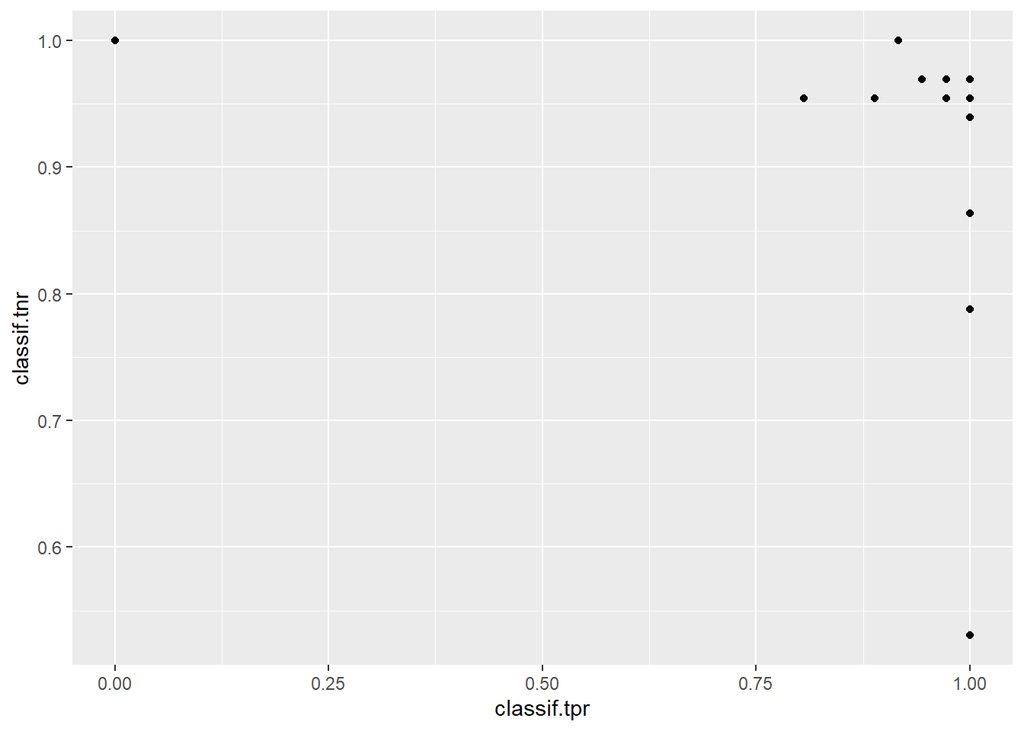

```r
library(ggplot2)
svm_learner_tuned$archive$data %>%
  ggplot(aes(x=classif.tpr, y=classif.tnr)) +
  geom_point()
```

Now, let’s identify the best svm models in terms of balanced accuracy.

```r
svm_best <- which(
  svm_learner_tuned$result$classif.bacc ==
    max(svm_learner_tuned$result$classif.bacc))
svm_learner_tuned$result[svm_best]
```

| cost | kernel | degree | gamma | learner_param_vals | x_domain | classif.bacc | classif.acc | classif.tpr | classif.tnr |
| --- | --- | --- | --- | --- | --- | --- | --- | --- | --- |
| -6.057508 | linear | NA | NA |  |  | 0.9848485 | 0.9803922 | 1 | 0.969697 |
| -3.583279 | sigmoid | NA | -2.698639 |  |  | 0.9848485 | 0.9803922 | 1 | 0.969697 |
| -6.057508 | linear | NA | NA |  |  | 0.9848485 | 0.9803922 | 1 | 0.969697 |

We have a tie: three models with the same `bacc` of around 98.5%. We choose one of them (the first one) and define a new model `svm_learner_final` to be re-trained on training and validation data before we look at the test data.

```r
svm_best <- svm_best[1]
svm_learner_final <- lrn("classif.svm")
svm_learner_final$param_set$values <- svm_learner_tuned$result$learner_param_vals[[svm_best]]
svm_learner_final$param_set
```

```
## <ParamSet>
##                  id    class lower upper nlevels          default parents
##  1:       cachesize ParamDbl  -Inf   Inf     Inf               40
##  2:   class.weights ParamUty    NA    NA     Inf
##  3:           coef0 ParamDbl  -Inf   Inf     Inf                0  kernel
##  4:            cost ParamDbl     0   Inf     Inf                1    type
##  5:           cross ParamInt     0   Inf     Inf                0
##  6: decision.values ParamLgl    NA    NA       2            FALSE
##  7:          degree ParamInt     1   Inf     Inf                3  kernel
##  8:          fitted ParamLgl    NA    NA       2             TRUE
##  9:           gamma ParamDbl     0   Inf     Inf   <NoDefault[3]>  kernel
## 10:          kernel ParamFct    NA    NA       4           radial
## 11:              nu ParamDbl  -Inf   Inf     Inf              0.5    type
## 12:           scale ParamUty    NA    NA     Inf             TRUE
## 13:       shrinking ParamLgl    NA    NA       2             TRUE
## 14:       tolerance ParamDbl     0   Inf     Inf            0.001
## 15:            type ParamFct    NA    NA       2 C-classification
##                value
##  1:
##  2:
##  3:
##  4:      0.002340226
##  5:
##  6:
##  7:
##  8:
##  9:
## 10:           linear
## 11:
## 12:
## 13:
## 14:
## 15: C-classification
```

```r
svm_learner_final$train(bc_task_num)
```

We obtain test predictions and apply our custom function `classif_metrics.`

```r
svm_pred <- svm_learner_final$predict_newdata(bc_data_test_num)
svm_results <- classif_metrics(pred = svm_pred$response,
                               labels = svm_pred$truth,
                               "svm")
svm_results %>% t()
```

```
##                   svm
## acc        0.95906433
## acc_se     0.01515224
## acc_lower  0.92936649
## acc_upper  0.98876217
## tpr        0.95312500
## tpr_se     0.02642139
## tpr_lower  0.90134004
## tpr_upper  1.00490996
## tnr        0.96261682
## tnr_se     0.01833889
## tnr_lower  0.92667327
## tnr_upper  0.99856038
## bacc       0.95787091
## bacc_se    0.01608108
## bacc_lower 0.92635258
## bacc_upper 0.98938925
```

```r
rbind(lr_results, svm_results) %>% t()
```

```
##                    lr        svm
## acc        0.95321637 0.95906433
## acc_se     0.01614896 0.01515224
## acc_lower  0.92156499 0.92936649
## acc_upper  0.98486776 0.98876217
## tpr        0.95312500 0.95312500
## tpr_se     0.02642139 0.02642139
## tpr_lower  0.90134004 0.90134004
## tpr_upper  1.00490996 1.00490996
## tnr        0.95327103 0.96261682
## tnr_se     0.02040372 0.01833889
## tnr_lower  0.91328047 0.92667327
## tnr_upper  0.99326159 0.99856038
## bacc       0.95319801 0.95787091
## bacc_se    0.01669133 0.01608108
## bacc_lower 0.92048362 0.92635258
## bacc_upper 0.98591241 0.98938925
```

**Question: Is there a difference in terms of balanced accuracy between the best svm model and the baseline logistic regression model?**

- The confidence intervals for `bacc` clearly overlap, indicating no significant difference between the two models.

As we have a paired comparison here (both models are applied to the same test data set), we can choose an even more accurate method for statistical inference. We do this now by defining a new function `bacc_delta` by calculating a confidence interval for the difference in balanced accuracy.

```r
bacc_delta <- function(d, positive = "malignant"){

  pos <- d$labels == positive
  neg <- !pos

  y1 <- d$pred1 == d$labels
  y2 <- d$pred2 == d$labels

  n <- length(d$labels)
  n1 <- sum(pos)
  n0 <- sum(neg)

  bacc1 <- 0.5 * mean(y1[pos]) + 0.5 * mean(y1[neg])
  bacc2 <- 0.5 * mean(y2[pos]) + 0.5 * mean(y2[neg])
  delta <- bacc1 - bacc2

  return(delta)
}
```

Let’s create the required `data.frame` and calculate the `bacc` point estimate

```r
pred_data <- data.frame(pred1 = svm_pred$response,
                        pred2 = lr_pred$response,
                        labels = lr_pred$truth)
bacc_delta(pred_data)
```

```
## [1] 0.004672897
```

We still have not quantified the uncertainty associated with this estimate. Let’s do that now with the so-called bootstrap - a very versatile, nonparametric statistical inference technique.

```r
?boot::boot
?boot::boot.ci
```

```r
set.seed(1337)
boot::boot(
  data = pred_data,
  statistic = function(d, i){bacc_delta(d[i, ])},
  R = 2000) %>%
  boot::boot.ci()
```

```
## BOOTSTRAP CONFIDENCE INTERVAL CALCULATIONS
## Based on 2000 bootstrap replicates
##
## CALL :
## boot::boot.ci(boot.out = .)
##
## Intervals :
## Level      Normal              Basic
## 95%   (-0.0047,  0.0138 )   (-0.0069,  0.0093 )
##
## Level     Percentile            BCa
## 95%   ( 0.0000,  0.0163 )   ( 0.0000,  0.0275 )
## Calculations and Intervals on Original Scale
## Some BCa intervals may be unstable
```

**Question: How can these confidence interval(s) be interpreted?**

- The data does not indicate that there is a significance difference at the $\alpha=0.05$ level with regard to balanced accuracy between the baseline logistic regression model and the best SVM model.

## Exercise 4: Comparison of risk prediction models (30 minutes)

Binary classification seems to works quite well on the breast cancer task. Now we move to risk prediction instead. Risk prediction is more general, i.e. the trained model can predict class probabilities.

For this we, need to set `predict_type="prob"` in the learner definition.

```r
lr_learner_pr <- lrn("classif.log_reg", predict_type="prob")
lr_learner_pr$train(bc_task_num)
```

```r
lr_pred_pr <- lr_learner_pr$predict_newdata(bc_data_test_num)
lr_pred_pr
```

```
## <PredictionClassif> for 171 observations:
##     row_ids     truth  response prob.malignant  prob.benign
##           1    benign    benign    0.011252421 9.887476e-01
##           2 malignant malignant    0.999999844 1.560623e-07
##           3 malignant malignant    0.999980081 1.991869e-05
## ---
##         169 malignant malignant    0.997852486 2.147514e-03
##         170 malignant malignant    0.999572451 4.275488e-04
##         171    benign    benign    0.006505976 9.934940e-01
```

Note that we access the `bc_task` with ordinal features this time as the random forest learner is able to handle those.

```r
rf_learner_pr <- mlr3tuningspaces::lts(lrn("classif.ranger"))
rf_learner_pr$predict_type <- "prob"
rf_learner_pr$param_set

set.seed(1337)
rf_learner_pr_tuned <- mlr3tuning::tune(
  method = "random_search",
  task = bc_task,
  learner = rf_learner_pr,
  resampling = rsmp("holdout", ratio=0.8),
  measures = msrs(c("classif.auc")),
  term_evals = 40
)
```

```r
if(save_vars){
  saveRDS(rf_learner_pr_tuned, "data/session1/rf_learner_pr_tuned.rds")
}
rf_learner_pr_tuned <- readRDS("data/session1/rf_learner_pr_tuned.rds")
```

```r
rf_learner_pr_tuned$result
```

| replace | sample.fraction | num.trees | learner_param_vals | x_domain | classif.auc |
| --- | --- | --- | --- | --- | --- |
| TRUE | 0.5462003 | 1563 |  |  | 0.996633 |

Conduct the same steps as with the SVM models before.

```r
rf_best <- which.max(rf_learner_pr_tuned$result$classif.auc)
rf_best <- rf_best[1]
rf_learner_pr_final <- lrn("classif.ranger", predict_type = "prob")
rf_learner_pr_final$param_set$values <- rf_learner_pr_tuned$result$learner_param_vals[[rf_best]]
rf_learner_pr_final$param_set
```

```
## <ParamSet>
##                               id    class lower upper nlevels        default
##  1:                        alpha ParamDbl  -Inf   Inf     Inf            0.5
##  2:       always.split.variables ParamUty    NA    NA     Inf <NoDefault[3]>
##  3:                class.weights ParamDbl  -Inf   Inf     Inf
##  4:                      holdout ParamLgl    NA    NA       2          FALSE
##  5:                   importance ParamFct    NA    NA       4 <NoDefault[3]>
##  6:                   keep.inbag ParamLgl    NA    NA       2          FALSE
##  7:                    max.depth ParamInt     0   Inf     Inf
##  8:                min.node.size ParamInt     1   Inf     Inf              1
##  9:                     min.prop ParamDbl  -Inf   Inf     Inf            0.1
## 10:                      minprop ParamDbl  -Inf   Inf     Inf            0.1
## 11:                         mtry ParamInt     1   Inf     Inf <NoDefault[3]>
## 12:                   mtry.ratio ParamDbl     0     1     Inf <NoDefault[3]>
## 13:            num.random.splits ParamInt     1   Inf     Inf              1
## 14:                  num.threads ParamInt     1   Inf     Inf              1
## 15:                    num.trees ParamInt     1   Inf     Inf            500
## 16:                    oob.error ParamLgl    NA    NA       2           TRUE
## 17:        regularization.factor ParamUty    NA    NA     Inf              1
## 18:      regularization.usedepth ParamLgl    NA    NA       2          FALSE
## 19:                      replace ParamLgl    NA    NA       2           TRUE
## 20:    respect.unordered.factors ParamFct    NA    NA       3         ignore
## 21:              sample.fraction ParamDbl     0     1     Inf <NoDefault[3]>
## 22:                  save.memory ParamLgl    NA    NA       2          FALSE
## 23: scale.permutation.importance ParamLgl    NA    NA       2          FALSE
## 24:                    se.method ParamFct    NA    NA       2        infjack
## 25:                         seed ParamInt  -Inf   Inf     Inf
## 26:         split.select.weights ParamDbl     0     1     Inf <NoDefault[3]>
## 27:                    splitrule ParamFct    NA    NA       2           gini
## 28:                      verbose ParamLgl    NA    NA       2           TRUE
## 29:                 write.forest ParamLgl    NA    NA       2           TRUE
##                               id    class lower upper nlevels        default
##        parents     value
##  1:
##  2:
##  3:
##  4:
##  5:
##  6:
##  7:
```

[output cut: 8 more lines]

```
## 16:
## 17:
## 18:
## 19:                 TRUE
## 20:
## 21:            0.5462003
## 22:
## 23: importance
## 24:
## 25:
## 26:
## 27:
## 28:
## 29:
##        parents     value
```

```r
rf_learner_pr_final$train(bc_task)
```

Now we apply our model to the test data.

```r
rf_pred_pr <- rf_learner_pr_final$predict_newdata(bc_data_test)
rf_pred_pr
```

```
## <PredictionClassif> for 171 observations:
##     row_ids     truth  response prob.malignant  prob.benign
##           1    benign    benign   0.0242629660 0.9757370340
##           2 malignant malignant   0.9993921945 0.0006078055
##           3 malignant malignant   0.9977833125 0.0022166875
## ---
##         169 malignant malignant   0.8556530482 0.1443469518
##         170 malignant malignant   0.9783058628 0.0216941372
##         171    benign    benign   0.0002132651 0.9997867349
```

In the following we will make use of the R package `pROC` to estimate, plot and compare the ROC curve and area under the curve (AUC) of our two models

```r
library(pROC)
```

```r
?roc
?auc
?roc.test
```

**Task: Fill in the gaps to correctly define the ROC curve of the RF model.**

```r
lr_roc <- roc(response = lr_pred_pr$truth,
              predictor = lr_pred_pr$prob[, "malignant"],
              levels = c("benign", "malignant"))
rf_roc <- roc(response = rf_pred_pr$truth,
              predictor = rf_pred_pr$prob[, "malignant"],
              levels = c("benign", "malignant"))
```

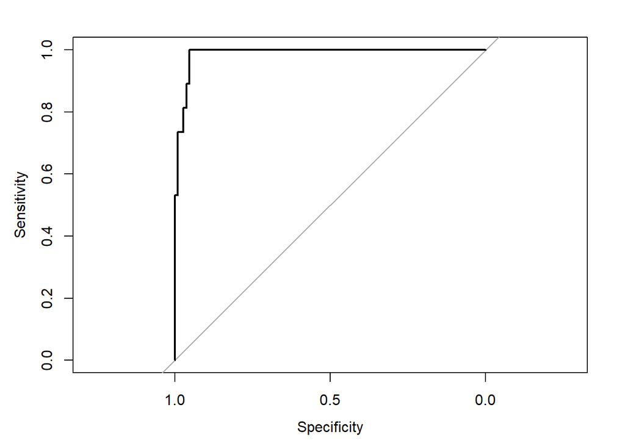

```r
plot(lr_roc)
```

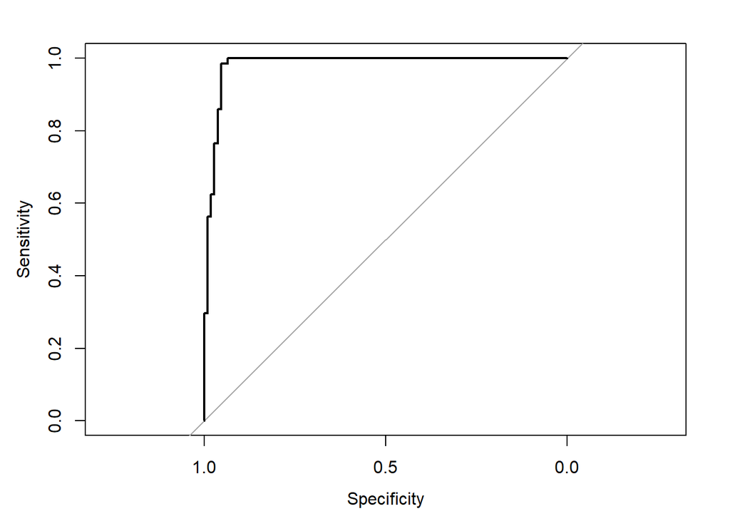

```r
plot(rf_roc)
```

Lets calculate the empirical area under the curves (AUCs).

```r
auc(rf_roc)
```

```
## Area under the curve: 0.982
```

```r
auc(lr_roc)
```

```
## Area under the curve: 0.9879
```

Finally, we conduct a significance test and calculate a confidence interval for the difference in AUCs.

```r
roc.test(rf_roc, lr_roc)
```

```
##
##  DeLong's test for two correlated ROC curves
##
## data:  rf_roc and lr_roc
## Z = -1.8553, p-value = 0.06355
## alternative hypothesis: true difference in AUC is not equal to 0
## 95 percent confidence interval:
##  -0.0120116149  0.0003293719
## sample estimates:
## AUC of roc1 AUC of roc2
##   0.9820386   0.9878797
```

**Question: How can these results be interpreted?**

- There is a small empirical difference in AUCs in favor of the (simpler) logistic regression model. At the $\alpha = 0.05$ level this difference is not statistically significant.